# Difference-in-Differences

EC 325: Econometrics

Prof. Caraher

Colby College

2026-04-14

## Econometrics So Far

- Started with the “gold standard” of causal inference: **RCTs**
- Next best alternative: **multivariate OLS**
- Even better: **Panel data with fixed-effects**
- Now: Using control **units** instead of control **variables**

## Multivariate OLS and its Discontents

- Often, even when we include control variables, we still have OVB
  - Example: Unobserved ability, geography, etc.
- In many of those cases, *if we have panel data* we can use **fixed-effects** to control for either:
  - Unit-specific, time-invariant factors
  - Unit-common, time-variant shocks
- But what if that *still isn’t good enough?*
  - e.g., unit-specific, time-variant factors can’t be accounted for!
- Instead of relying purely on **control variables**, a (perhaps better) choice is to use **control units**

## “As Good As” Random Selection

- We saw how an RCT *eliminates the selection bias term*
  - The random assignment of units to the *treated* vs. *control* groups ensured there was no systemic differences between groups
- However, the whole point of this semester on regression is that often RCTs are often not possible
- But what if we could find control units such that units were **as good as randomly assigned** into treatment and control groups
- This would also eliminate the selection bias term!

## Randomized vs. Natural Experiments

- When we want to eliminate the selection bias term, but cannot use an RCT, we can instead leverage **natural experiments**

**Natural Experiments**

A **Natural Experiment** is a study based on observational data where the “treatment” is assigned by forces outside the researcher’s control, such as **nature**, **policy changes**, or **other events**. Natural experiments create the conditions which *resemble random assignment*.

- If a natural experiment (as good as) randomly assigns units into either a “treated” or “control” group, then this could also ensure our comparison between these groups is not plagued by selection bias

## Example: The Effect of Immigration on Native Wages

- Suppose you want to study the effect of immigration on wages across US cities
- A naive regression may look like the following:

$$native\_wage = \beta_0 + \beta_1(immigrant\_share) + \mu$$

- What are some of the issues with this regression?
  - OVB: immigrants probably move to cities which are **economically doing well**
- Even if we were to include **control variables** we may not be able to account for really important unobservable factors
  - E.g., what is the economic **trajectory** like in our cities (can’t be fixed using city FEs)?
- So what can we do when control variables won’t give us a plausible causal estimate?

# The Mariel Boatlift

## The Mariel Boatlift

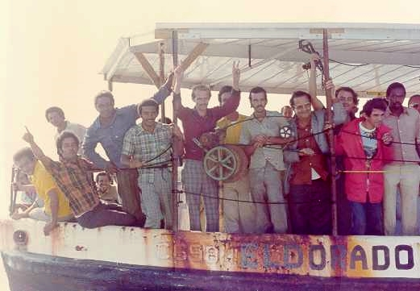

Mariel refugees arriving in Miami

- In 1980, Cuba experienced a serious economic downturn
- Things got so bad that Castro allowed anyone who wanted to to leave the country
- Between April and October of 1980, **125,000** “Marielitos” left Cuba from **Mariel Harbor** and arrived in **Miami**

## The Mariel Boatlift as Natural Experiment

- This mass exodus of Cubans to the Miami had *nothing to do with labor market conditions*
- It was solely due to a) policy in Cuba, and b) the geographic proximity of Miami to Cuba
- In other words, the “treatment” of a large number of immigrants is **as good as randomly assigned** to Miami!

## Card (1990) Overview

- David Card (1990) uses the boatlift as a **natural experiment** to study the effects of immigration on wages and employment
- Specifically, he compares labor market outcomes in 1979 (before the boatlift) to those 5 years later

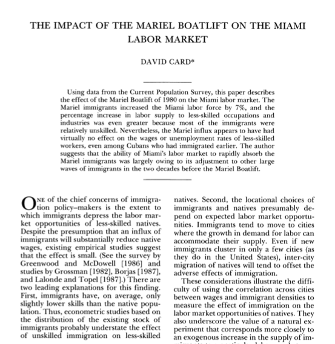

David Card’s 1990 Paper

## Difference in Wages in Miami

- Card (1990) first finds the **difference** in (log) wages in Miami from **1979** (before the Boatlift) to the (average) of **1980 to 1985** (after the Boatlift)
- He focuses on *white, non-Hispanic* workers since they are most likely non-immigrants

| City | Pre (1979) | Post (1980-1985) | Diff (Post - Pre) |
| --- | --- | --- | --- |
| Miami | 1.85 | 1.83 | -0.02 |

- Can we think of this pre-post difference as a **causal effect** of immigration?
- **No!**
  - Employment conditions could have worsened not only in Miami, but everywhere else!
  - Only looking at changes in our *treated unit* may *mislead* us into thinking that those changes are **caused** by our treatment

## Control Cities

- We have to compare the changes in our **treated unit** to changes in **control units**
  - Otherwise, we may confuse the effects of a **broader trend** with our **specific treatment**
- Miami (Card argues) would have had the **same change in LM outcomes** as a set of **similar “control” cities** had it not experienced the Boatlift (i.e., was not “treated”)
- Which cities do you think might be good “controls” for Miami?

## Control Cities and Counter-Factuals

- Card (1990) uses **Atlanta, Los Angeles, Houston, and Tampa-St. Petersburg** as the control cities
- He uses the average of LM outcomes in these cities as the **controls** for the “psuedo-randomly treated” Miami
- In other words, he is assuming that Atlanta, Los Angeles, Houston, and Tampa-St. Petersburg form a good **counter-factual** group for Miami

**Counter-Factuals**

A **counter-factual** is a “what if” scenario used to measure the causal impact of a policy, event, or decision. It works by comparing the actual outcome (what really happened) to a hypothetical outcome (what would have happened without the event). This hypothetical, “do-nothing” scenario is the counterfactual.

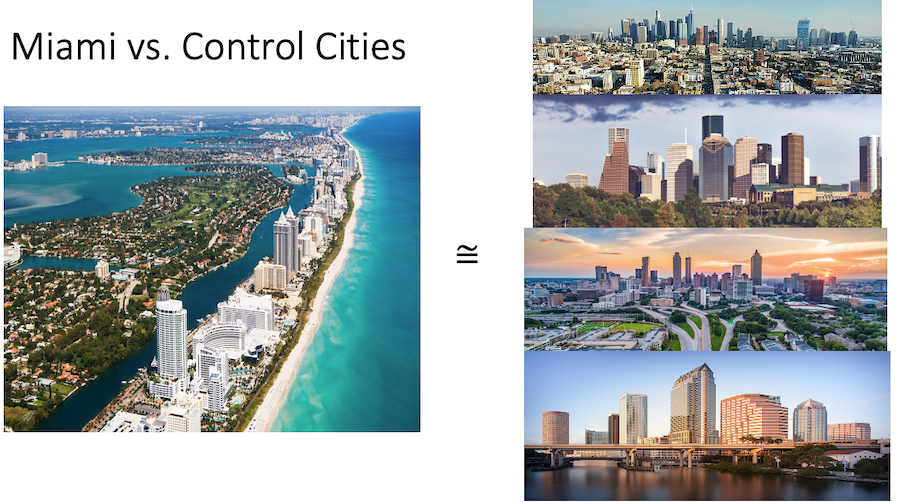

Miami vs. Control Cities

## The Effect of Immigration on Native Wages

| City | Pre (1979) | Post (1980-1985) | Diff (Post - Pre) |
| --- | --- | --- | --- |
| Miami | 1.85 | 1.83 | -0.02 |
| Controls | 1.93 | 1.91 | -0.02 |

## The Effect of Immigration on Native Wages

| City | Pre (1979) | Post (1980-1985) | Diff (Post - Pre) |
| --- | --- | --- | --- |
| Miami | 1.85 | 1.83 | -0.02 |
| Controls | 1.93 | 1.91 | -0.02 |
| Treated - Control |  |  | **0.00** |

- The **causal effect** of immigration is thus the *change in outcome in our treated group* minus the *change in outcome of our control group*
- This difference between the pre-post changes between the two groups nets out any difference in employment that would have happened *had the treatment not occurred*
- This method of **double differencing** is called the **difference-in-differences**

# DiD: The Formal Framework

## Estimating with Natural Experiments

- Card (1990) has **panel data** and can use it to recover the **causal effect of immigration**
- How? With a **Difference-in-Differences** (DiD) estimator

## Difference-in-Differences

- Assume we have *two groups*:
  - a **treated group** where $D_{i} = 1$ (i.e., Miami)
  - an **untreated group** where $D_{i} = 0$ (i.e., the other 4 cities)
- Also assume we have two *time periods*:
  - a **pre-treatment** period where $P_{t} = 0$ (i.e., 1979)
  - a **post-treatment** period where $P_{t} = 1$ (i.e., 1980-1985)

## Potential Outcomes, Revisited

- Recall our **Potential Outcomes Framework**
  - Every unit $Y_{it}$ has both a *treated outcome*, $Y_{it}(1)$
  - and a parallel universe with an *untreated outcome*, $Y_{it}(0)$
- Define the **average treatment effect on the treated (ATT)** of $X$ on $Y$ as:

$$ATT = E[Y_{i,1}(1) | D_{i} = 1] - E[Y_{i,1}(0) | D_{i} = 1]$$

- In other words, the **ATT** is the (expected) difference between:
  - what *did* happen to the treatment group and,
  - what *would have happened* to them if they hadn’t been treated (i.e., “parallel universe” Miami)

## Estimating the ATT

- Recall the **fundamental problem of causal inference** is that
  - we can never observe both potential outcomes at the same time
- We *can* observe $E[Y_{i,1}(1) | D_{i} = 1]$
  - This is simply the average outcome of the treated group in the post-period
- We *cannot* observe $E[Y_{i,1}(0) | D_{i} = 1]$
  - This is the *hypothetical outcome:* what would have happened to the treated group in the post-period if the treatment never existed?
- If we don’t observe this second term, then how do we estimate the **ATT**?

## The Parallel Trends Assumption

- The **core assumption** of the difference-in-differences method

**Parallel Trends Assumption**

The **Parallel Trends Assumption** states that, in the absence of treatment, the average outcome for the treated group would have followed the **same trend** as the average outcome for the control group:
$$E[Y_{i1} - Y_{i0} | D_i = 1] = E[Y_{i1} - Y_{i0} | D_i = 0]$$

- **LHS:** the *unobservable* trend the treated group would have experienced without the treatment
- **RHS:** the *observable* trend of the control group

## The DiD Estimator

- Plugging the **parallel trends assumption** into the formula for the **ATT**, we get the **difference-in-differences estimator**:

$$\begin{aligned}
\underbrace{ATT}_{\text{treatment effect}} = &\underbrace{(E[Y_{i1} | D_i = 1] - E[Y_{i0} | D_i = 1])}_{\text{trend for treated group}} \\
& - \underbrace{(E[Y_{i1} | D_i = 0] - E[Y_{i0} | D_i = 0])}_{\text{trend for control group}}
\end{aligned}$$

## Visualizing the DiD Estimator

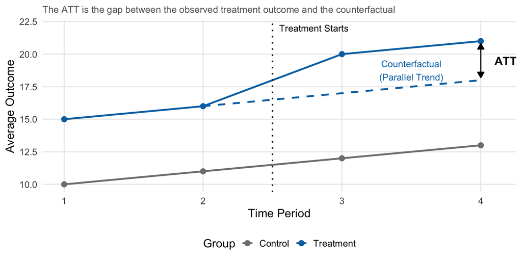

# The DiD Regression

## The DiD Regression

- We usually use a regression to estimate the **ATT**
- The **DiD Regression** is estimated as:

$$y_{it} = \beta_0 + \beta_1D_{i} + \beta_2P_{t} + \delta(D_{i} \times P_{t}) + \mu_{it}$$

where:

- $D_i$ is the “treated group indicator”, a dummy variable (1 if treated group, 0 if control)
- $P_t$ is the “post-period indicator”, a dummy variable (1 if post-period, 0 if pre-period)
- $D_{i} \times P_{t}$ is the interaction term
- $\delta$ is the **treatment effect** (ATT)

## How the DiD Regression Works

- How does this regression work to estimate the ATT? Think about the *predicted outcome* $y_{it}$ for each of the 4 combos:

| Group ($D_i$) | Period ($P_t$) | Predicted Outcome ($\hat{y}_{it}$) |
| --- | --- | --- |
| Control ($D_i = 0$) | Pre ($P_t = 0$) | $\beta_0$ |
| Control ($D_i = 0$) | Post ($P_t = 1$) | $\beta_0 + \beta_2$ |
| Treated ($D_i = 1$) | Pre ($P_t = 0$) | $\beta_0 + \beta_1$ |
| Treated ($D_i = 1$) | Post ($P_t = 1$) | $\beta_0 + \beta_1 + \beta_2 + \delta$ |

- Plugging in the predicted outcomes,
  - (Trend for treatment group) = (treated, post) - (treated, pre) = ($\beta_0 + \beta_1 + \beta_2 + \delta) - (\beta_0 + \beta_1) = \beta_2 + \delta$
  - (Trend for control group) = (control, post) - (control, pre) = ($\beta_0 + \beta_2$) - ($\beta_0$) = $\beta_2$
  - ATT = (Trend for treatment group) - (Trend for control group) = ($\beta_2 + \delta) - (\beta_2) = \delta$

## Estimating the DiD Regression

- Let’s re-estimate the Card (1990) results but using the **DiD regression**

```r
# Create the Card (1990) data
miami_wages <- tibble(city = "miami", year = 1979:1985,
    wages = c(1.85, 1.83, 1.85, 1.82, 1.82, 1.82, 1.82))

control_wages <- tibble(city = "control", year = 1979:1985,
    wages = c(1.93, 1.90, 1.91, 1.91, 1.90, 1.91, 1.92))

boatlift_data <- bind_rows(miami_wages, control_wages) |>
    mutate(post = ifelse(year >= 1980, 1, 0),
           treated = ifelse(city == "miami", 1, 0),
           post_treat = post * treated)

did_reg <- feols(wages ~ treated + post + post_treat,
                 vcov = "HC1", data = boatlift_data)
summary(did_reg)
```

```
OLS estimation, Dep. Var.: wages
Observations: 14
Standard-errors: Heteroskedasticity-robust
             Estimate Std. Error       t value   Pr(>|t|)
(Intercept)  1.930000 0.00000100  1.930000e+06  < 2.2e-16 ***
treated     -0.080000 0.00000100 -8.000000e+04  < 2.2e-16 ***
post        -0.021667 0.00331942 -6.527254e+00 6.6615e-05 ***
post_treat  -0.001667 0.00628785 -2.650620e-01 7.9635e-01
---
Signif. codes:  0 '***' 0.001 '**' 0.01 '*' 0.05 '.' 0.1 ' ' 1
RMSE: 0.008522   Adj. R2: 0.947329
```

# Two-Way Fixed Effects

## TWFE: Extending DiD

- But what if we have **many treated and/or control units** and **many time periods**?
- An *even more flexible* regression for estimating **DiD** is the **Two-Way Fixed Effects** (TWFE) regression
  - with simple 2x2 DiD, it will give you the same results as differencing and the DiD regression

$$y_{it} = \delta(D_{it}) + \alpha_{i} + \tau_{t} + \mu_{it}$$

where:

- $y_{it}$ is our outcome for unit $i$ at time $t$
- $D_{it}$ is a dummy variable that equals 1 only for treated units *and* in post-treatment periods (i.e., our $D_{i} \times P_{t}$ interaction)
- $\alpha_{i}$ are *unit-specific* fixed effects
- $\tau_{t}$ are *time-specific* fixed effects
- $\mu_{it}$ is the error term
- $\delta$ is our estimate of the **ATT** AKA the *treatment effect*

## Why TWFE = Simple DiD in the 2x2 Case

In the 2x2 case, the fixed effects simplify:

- **Unit FE** with 2 groups $\rightarrow$ one dummy $D_i$ (= $\beta_1 D_i$)
- **Time FE** with 2 periods $\rightarrow$ one dummy $P_t$ (= $\beta_2 P_t$)
- $D_{it}$ = 1 only for treated in post $\rightarrow$ same as $D_i \times P_t$

Substituting:
$$y_{it} = \underbrace{(\alpha_0 + \tau_0)}_{\beta_0} + \underbrace{\alpha_1}_{\beta_1} D_i + \underbrace{\tau_1}_{\beta_2} P_t + \delta(D_i \times P_t) + \mu_{it}$$

This **is** the simple DiD regression. Same model, same estimate.

The advantage of TWFE: it generalizes to many units and many periods automatically.

## TWFE in R

- Let’s re-estimate this DiD but now using TWFE:

```r
twfe_reg <- feols(wages ~ post_treat | city + year,
                  vcov = "HC1", data = boatlift_data)
summary(twfe_reg)
```

```
OLS estimation, Dep. Var.: wages
Observations: 14
Fixed-effects: city: 2,  year: 7
Standard-errors: Heteroskedasticity-robust
            Estimate Std. Error   t value Pr(>|t|)
post_treat -0.001667   0.006491 -0.256776  0.80758
---
Signif. codes:  0 '***' 0.001 '**' 0.01 '*' 0.05 '.' 0.1 ' ' 1
RMSE: 0.00622     Adj. R2: 0.943875
                Within R2: 0.002193
```

- Same $\hat{\delta}$ as the simple DiD regression — as expected

## Comparing the Two Models

```r
modelsummary(list("Simple DiD" = did_reg, "TWFE" = twfe_reg),
             stars = TRUE,
             gof_omit = "AIC|BIC|Log|RMSE|Std")
```

|  | Simple DiD | TWFE |
| --- | --- | --- |
| (Intercept) | 1.930*** |  |
|  | (0.000) |  |
| treated | -0.080*** |  |
|  | (0.000) |  |
| post | -0.022*** |  |
|  | (0.003) |  |
| post_treat | -0.002 | -0.002 |
|  | (0.006) | (0.006) |
| Num.Obs. | 14 | 14 |
| R2 | 0.959 | 0.978 |
| R2 Adj. | 0.947 | 0.944 |
| R2 Within |  | 0.002 |
| R2 Within Adj. |  | -0.197 |
| FE: city |  | X |
| FE: year |  | X |

+ p < 0.1, * p < 0.05, ** p < 0.01, *** p < 0.001

## Did Card (1990) Pick Good Controls?

Card argues he chose these four cities (Atlanta, Los Angeles, Houston, and Tampa-St. Petersburg) because:

> “they had relatively large populations of Blacks and Hispanics and because they exhibited a patterns of growth similar to that in Miami over the late 1970s and early 1980s. A comparison of employment growth rates… suggests that economic conditions were very similar in Miami and the average of the four comparison cities between 1976 and 1984.”

## Did Card (1990) Pick Good Controls?

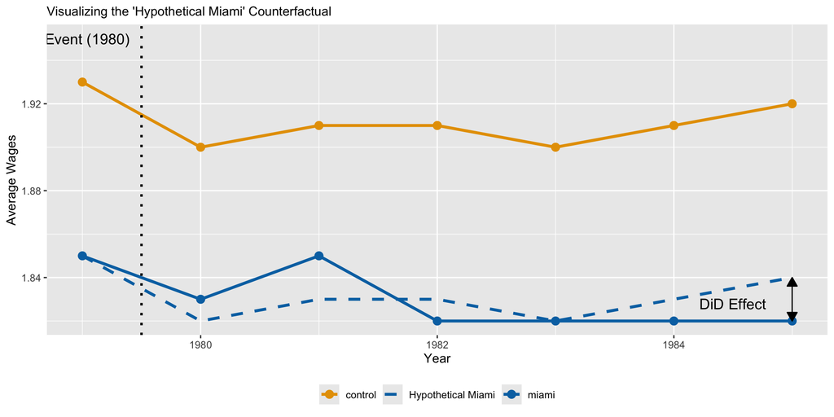

## Did Card (1990) Pick Good Controls?

- To me, they seem pretty solid
- The control group’s recession in 1979 seems to match that in Miami pretty well
- But, others may argue differently!

## Key Takeaways: DiD Estimation

- The goal of DiD is to estimate the **ATT** (Average Treatment Effect on the Treated).
- We can’t observe the treated group’s counterfactual, so we *assume* their trend would have been the same as the control group’s.
- This is the **Parallel Trends Assumption**, the single most important assumption in DiD.
- The 2x2 DiD model is:

$$y_{it} = \beta_0 + \beta_1D_{i} + \beta_2P_{t} + \delta(D_{i} \times P_{t}) + \mu_{it}$$

- The coefficient $\delta$ on the interaction term *is* the DiD estimate (the ATT).
- A more general way to estimate this is the **Two-Way Fixed Effects (TWFE)** model:

$$y_{it} = \delta(D_{it}) + \alpha_{i} + \tau_{t} + \mu_{it}$$

# Research Design and DiD

## Research Design

The goal of your research design is to build a believable “what if” scenario.

### What is the Research Design?

- It’s your method for choosing **control units** (the “comparison group”).
- A “good” control group is one that believably shows what *would have* happened to your treated group if the intervention never occurred.
- This “what if” scenario is the **counterfactual**.

### The Identifying Assumption

- Your entire research design hinges on one *critical, non-provable* assumption: the **Parallel Trends Assumption**.
- **In plain English:** This assumes that, *in the absence of the treatment*, the treatment and control groups’ outcomes would have followed the same trend.

## Why Does It Matter?

- Your causal estimate (the **ATT**) is only as valid as your counterfactual!

**Good Controls $\rightarrow$ Good Counterfactual $\rightarrow$ Good DiD Estimate**

**Bad Controls $\rightarrow$ Bad Counterfactual $\rightarrow$ Bad DiD Estimate**

## Two Paths to a Counterfactual

### “Intuition-Driven” Selection

- Choosing control units based on existing knowledge, theory, or clear historical similarities
- **Pros:** Logic is easy to explain and intuitive; grounded in real-world knowledge
- **Cons:** May not be obvious for everyone; intuition may not always be the best tool to rely on

### “Data-Driven” Selection

- Using an algorithm to find the control group that best matches (pre-period) observable variables for the treated group
- **Pros:** Not based on the researcher’s opinions; useful when no clear intuitive control group exists
- **Cons:** Can lead to confusing counterfactuals; data hungry; fitting on “noise” rather than “data”
- Importantly, these are not mutually exclusive!
  - Data-driven methods may confirm your intuition
  - Intuition may lead you to a set of good controls that you couldn’t derive using data

# Simulation: Good vs. Bad Controls

## The Scenario

Suppose **State A** expanded Medicaid in 2015 and we want to estimate the effect on the **uninsured rate** using DiD.

- The **true ATT** is **−4.0 percentage points**
- We observe 3 potential controls that *did not* expand Medicaid
- Which ones should we use?

## The Three Potential Controls

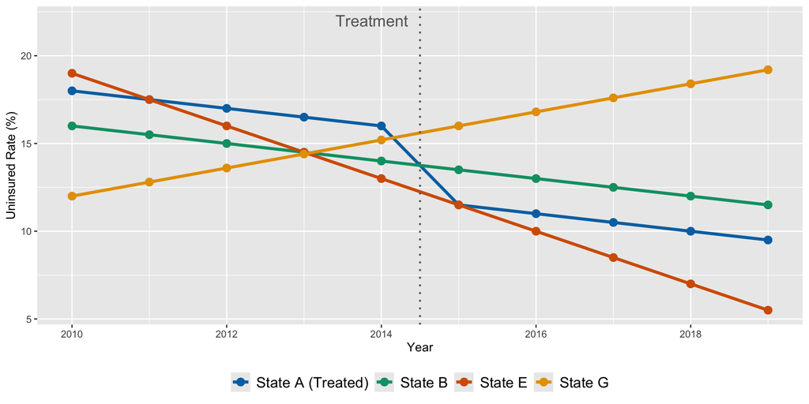

## Which States Have Parallel Pre-Trends?

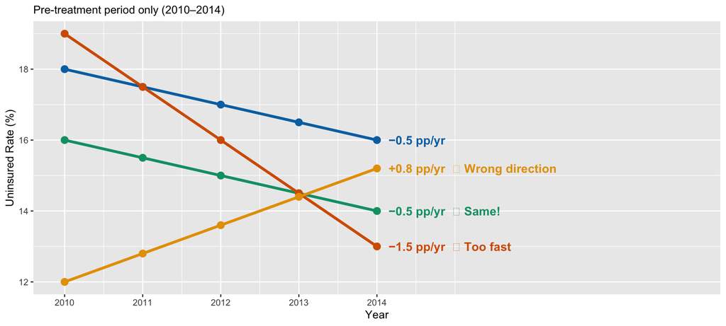

- **State B** has the same pre-trend as State A → **good control**
- **State E** is declining faster → **bad control**
- **State G** is going the other direction → **bad control**

## Good Control: State B (Parallel Trends)

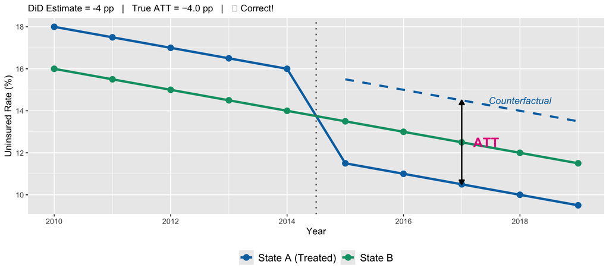

## Bad Control: State E (Faster Decline)

State E’s uninsured rate was falling at **−1.5 pp/yr** — *three times faster* than State A.

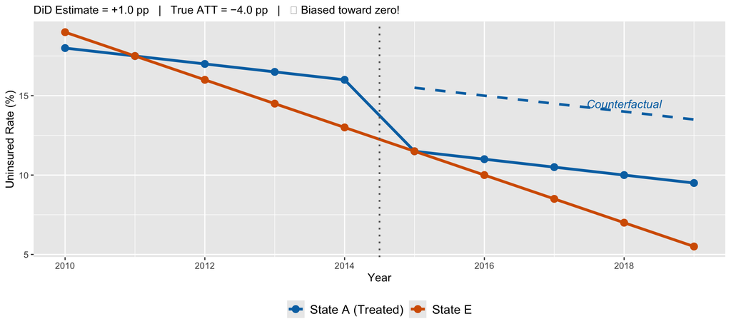

- The control is declining so fast that DiD “subtracts too much” — making the treatment look **smaller** than it really is

## Bad Control: State G (Rising Trend)

State G’s uninsured rate was *rising* at **+0.8 pp/yr** — the opposite direction of State A.

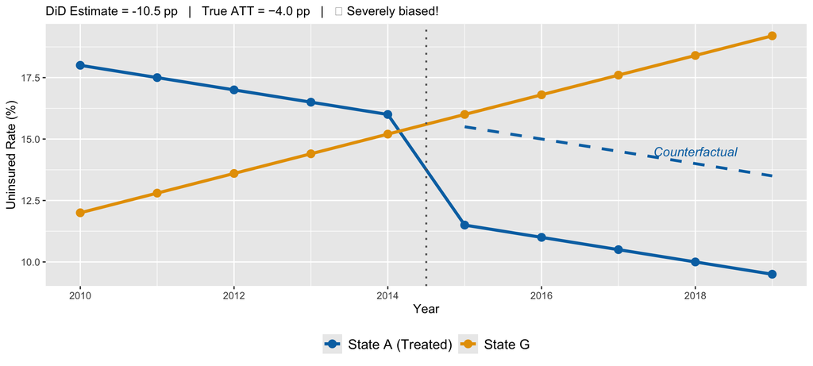

- The control is *rising* while the treated is falling, so DiD dramatically **overstates** the effect

## Summary: How Controls Change the Estimate

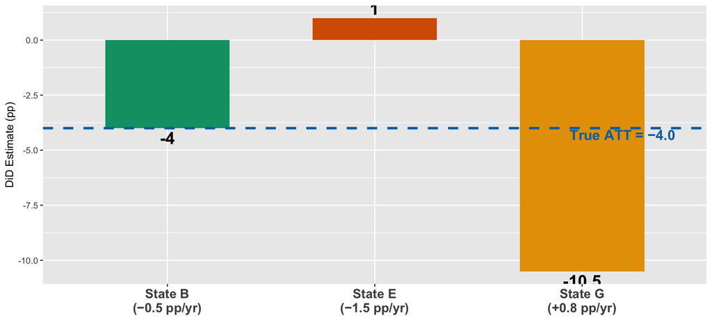

## Key Lesson

- **Parallel trends is everything.** A control is “good” if and only if it was on the **same trend** as the treated unit before treatment.
- **Levels don’t matter.** State B has a *different* uninsured rate from State A, but *the same trend* — and it gives the right answer.
- **The direction of bias is predictable:**
  - Control declines **faster** → bias **toward zero** (underestimate)
  - Control is **flat or rising** → bias **away from zero** (overestimate)
- **This is the “art” of applied econometrics:** finding controls where parallel trends is *credible*, and defending that choice.

# Choosing Controls in Practice

## Example: Minimum Wages and Employment

- What is the effect of minimum wages on employment?
- A naive approach: compare *all* states that raise MW (“treated”) to *all* states that don’t (“controls”)
- Problem: these groups are **very different** (political leaning, education, industry mix, etc.)

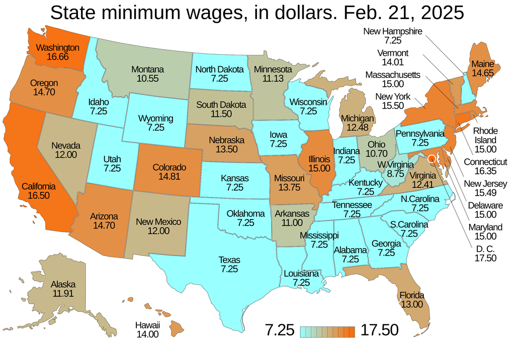

State-level Min. Wages

## Card and Krueger (1994)

- In 1992, NJ raised its minimum wage; nearby PA did not
- Card & Krueger: compare fast-food restaurants **right next to each other** on either side of the NJ/PA border
- **Key insight:** geographic proximity makes these restaurants likely to be on **parallel trends**
- Found: MW increase did *not* reduce employment

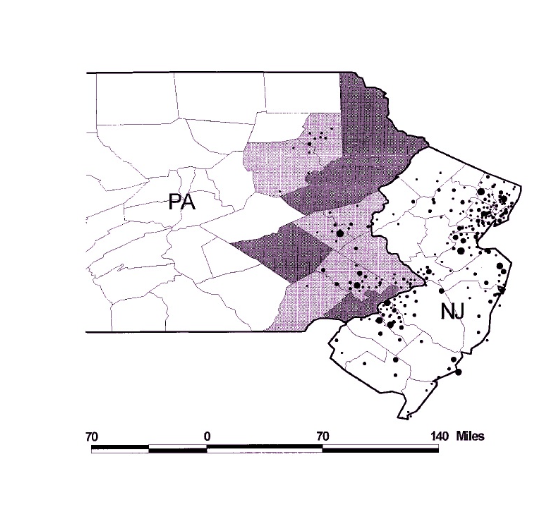

Map of surveyed restaurants

This is an example of choosing controls **based on intuition** — using geographic proximity to ensure parallel trends is credible.

## What Can Go Wrong

- **Differential pre-trends:** Groups already diverging before treatment
  - $\rightarrow$ DiD confuses pre-existing trend with treatment effect
- **Anticipation effects:** Units change behavior before treatment arrives
  - $\rightarrow$ Contaminates the “pre-treatment” data
- **Spillovers:** Treatment affects control units too
  - $\rightarrow$ Control group no longer reflects “no treatment”
- **Composition changes:** Mix of units changes over time
  - $\rightarrow$ Comparing different populations pre vs. post

## Assessing Parallel Trends

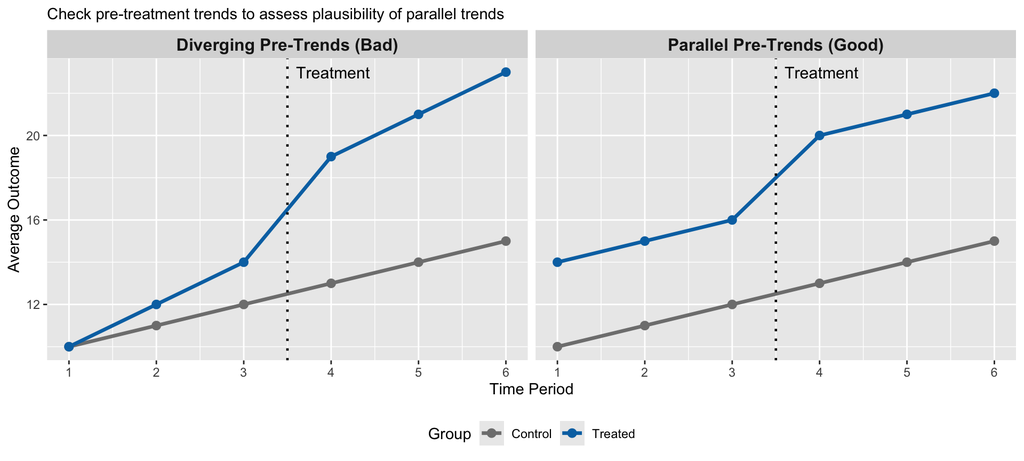

## Key Takeaways: Research Design

- Your DiD estimate is only as good as your **research design**
- The goal is to choose a control group that makes **parallel trends** as credible as possible
- A weak design compares very different units; a strong design compares very similar ones
- This is the “art” of econometrics: justifying *why* your comparison group provides a valid counterfactual

# Unit 12 Lab